# Praktikum Pertemuan 6&7

Uiwang Nur Thoriq

2023-10-30

## Package

```r
library(readxl)
library(ggplot2)
library(tsibble)
library(tseries)
library(MASS)
library(forecast)
library(TSA)
library(TTR)
library(aTSA)
library(graphics)
library(rio)
library(imputeTS)
```

## Input Data dan Time Series

```r
Data8<-read_xlsx("D:/MPDW/NVDA.xlsx",sheet="fix")
Data8<-Data8$`NVDA fix`
Data8<- na_interpolation(Data8)
Data8.ts<-ts(Data8)
```

## Eksplorasi

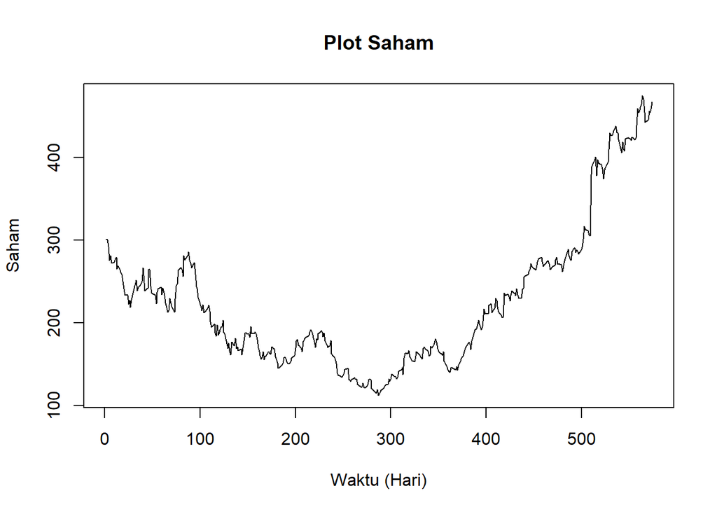

```r
plot.ts(Data8.ts, lty=1, xlab="Waktu (Hari)", ylab="Saham", main="Plot Saham")
```

Berdasarkan plot data deret waktu, terlihat bahwa data cenderung memiliki trend yang naik turun. Berdasarkan pola data, pembagian data latih dan data uji ditetapkan dengan proporsi 85%:15%.

## Data Latih

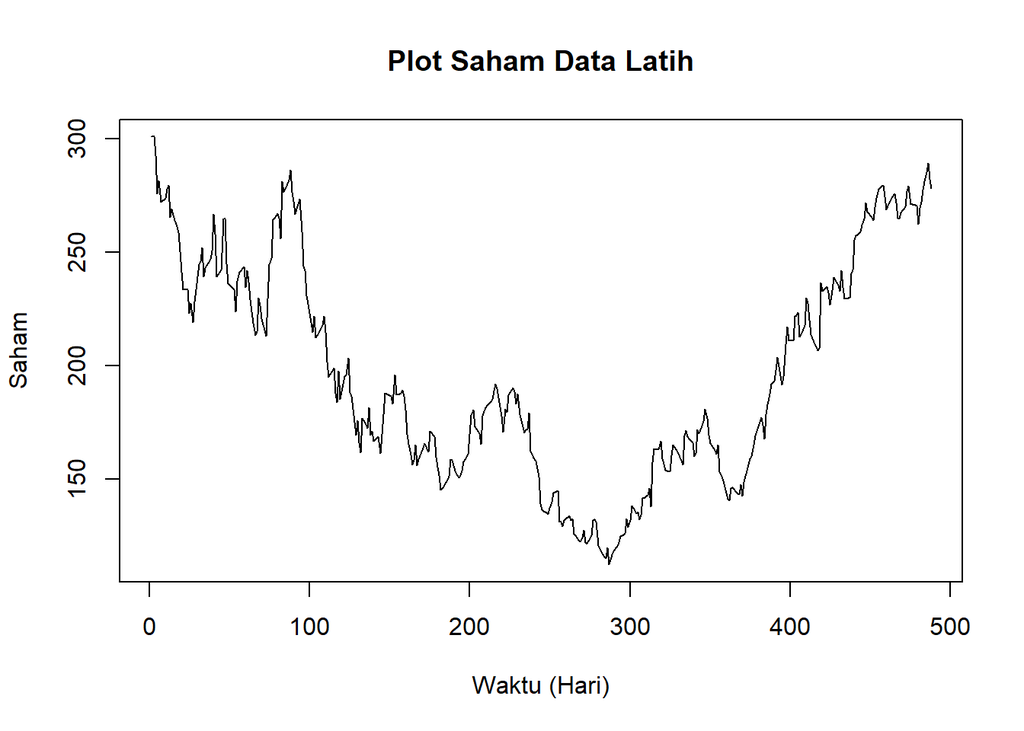

```r
Data8.train<-Data8[1:488]
train.ts<-ts(Data8.train)
plot.ts(train.ts, lty=1, xlab="Waktu (Hari)", ylab="Saham", main="Plot Saham Data Latih")
```

Berdasarkan plot data latih, terlihat bahwa data cenderung memiliki trend yang turun kemudian naik dan tidak stasioner.

## Data Uji

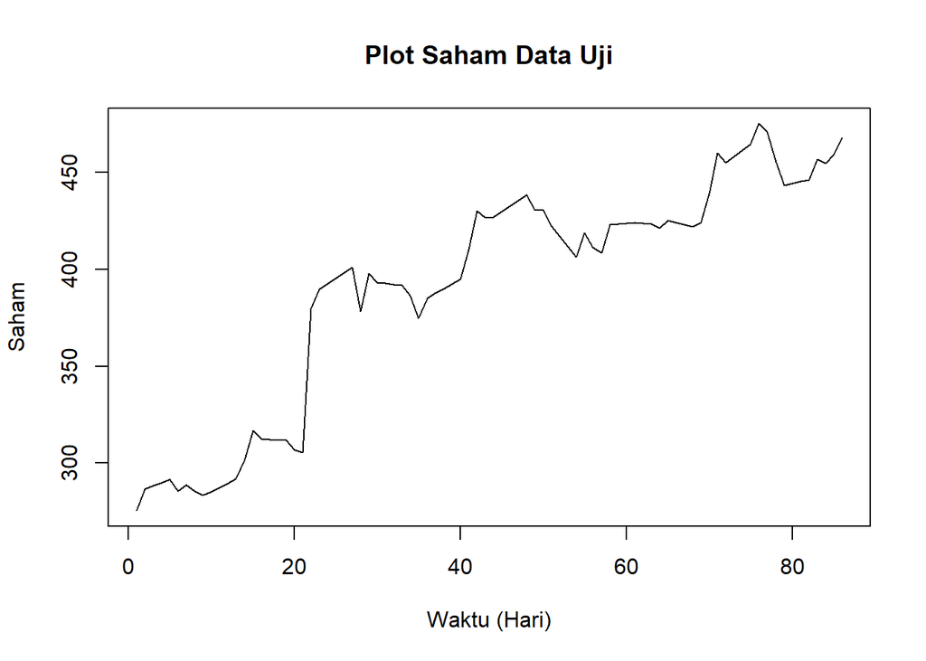

```r
Data8.test<-Data8[489:574]
test.ts<-ts(Data8.test)
plot.ts(test.ts, lty=1, xlab="Waktu (Hari)", ylab="Saham", main="Plot Saham Data Uji")
```

Plot dari data uji juga menunjukkan bahwa data memiliki pola tren naik dan tidak stasioner.

## Uji Kestasioneran Data

### Plot ACF

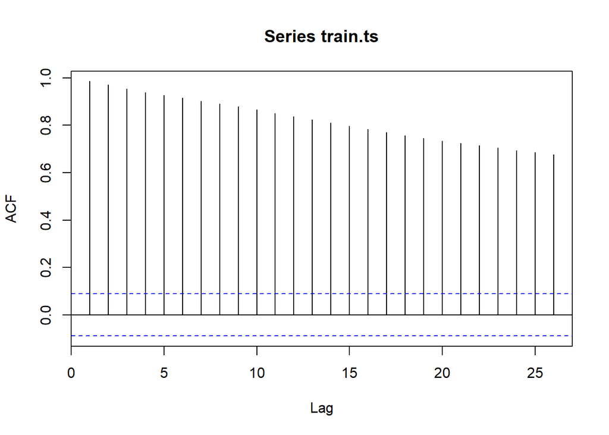

```r
acf(train.ts)
```

Berdasarkan plot ACF, terlihat bahwa data menurun secara perlahan (*tails of slowly*). Hal ini menjadi indikasi bahwa data tidak stasioner dalam rataan.

### Uji ADF

```r
tseries::adf.test(train.ts)
```

```
##
##  Augmented Dickey-Fuller Test
##
## data:  train.ts
## Dickey-Fuller = -1.0987, Lag order = 7, p-value = 0.9227
## alternative hypothesis: stationary
```

Berdasarkan uji ADF tersebut, didapat *p-value* sebesar 0.9227 yang lebih besar dari taraf nyata 5% sehingga menandakan bahwa data tidak stasioner dalam rataan. Hal ini sesuai dengan hasil eksplorasi menggunakan plot time series dan plot ACF, sehingga ketidakstasioneran model dalam rataan kedepannya harus ditangani.

### Plot Box-Cox

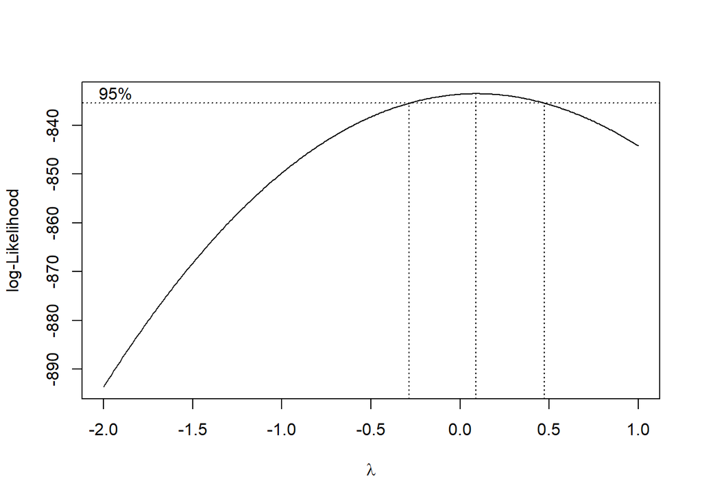

```r
index <- seq(1:length(train.ts))
bc = boxcox(train.ts~index, lambda = seq(-2,1,by=0.01))
```

```r
lambda <- bc$x[which.max(bc$y)]
lambda
```

```
## [1] 0.09
```

```r
bc$x[bc$y > max(bc$y) - 1/2 * qchisq(.95,1)]
```

```
##  [1] -0.28 -0.27 -0.26 -0.25 -0.24 -0.23 -0.22 -0.21 -0.20 -0.19 -0.18 -0.17
## [13] -0.16 -0.15 -0.14 -0.13 -0.12 -0.11 -0.10 -0.09 -0.08 -0.07 -0.06 -0.05
## [25] -0.04 -0.03 -0.02 -0.01  0.00  0.01  0.02  0.03  0.04  0.05  0.06  0.07
## [37]  0.08  0.09  0.10  0.11  0.12  0.13  0.14  0.15  0.16  0.17  0.18  0.19
## [49]  0.20  0.21  0.22  0.23  0.24  0.25  0.26  0.27  0.28  0.29  0.30  0.31
## [61]  0.32  0.33  0.34  0.35  0.36  0.37  0.38  0.39  0.40  0.41  0.42  0.43
## [73]  0.44  0.45  0.46  0.47
```

Plot Boxcox menunjukkan nilai *rounded value* ($\lambda$) optimum sebesar **0,09** dan pada selang kepercayaan 95% nilai memiliki batas bawah **-0,28** dan batas atas **0.47**. Selang tersebut tidak memuat nilai satu sehingga dapat dikatakan bahwa data bangkitan tidak stasioner dalam ragam.

## Penanganan Ketidakstasioneran

### Dalam Ragam

#### Tranformasi Boxcox

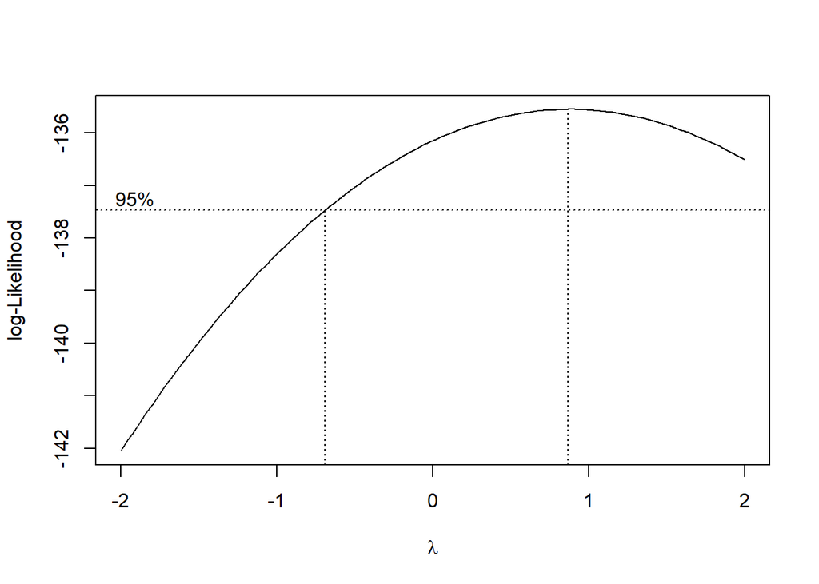

```r
train.baru<-(train.ts^lambda-1)/lambda
box<-boxcox(train.baru~index)
```

Selang tersebut memuat nilai satu sehingga dapat dikatakan bahwa data stasioner dalam ragam.

### Dalam Rataan

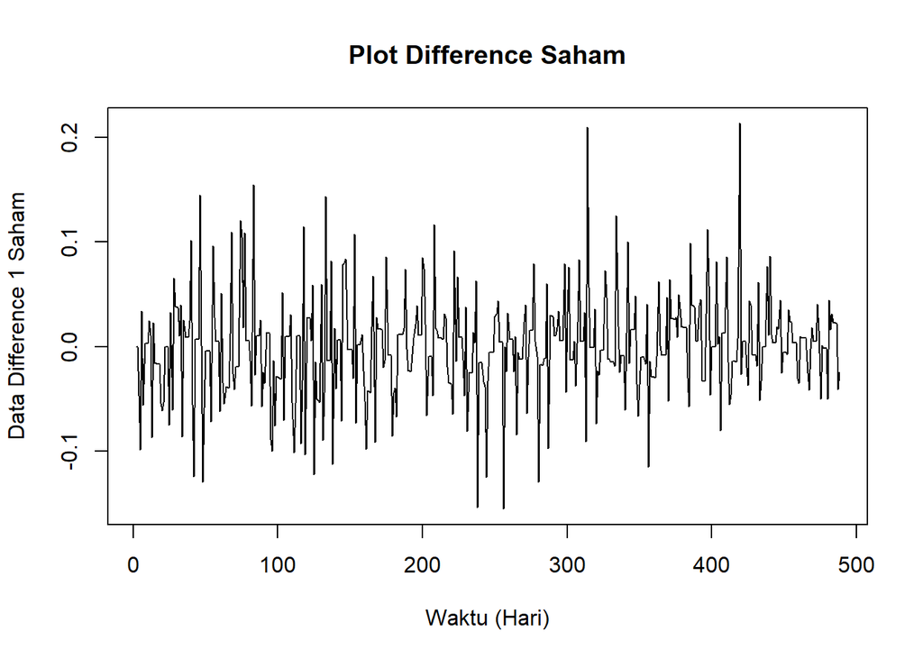

```r
train.diff<-diff(train.baru,differences = 1)
plot.ts(train.diff, lty=1, xlab="Waktu (Hari)", ylab="Data Difference 1 Saham", main="Plot Difference Saham")
```

Berdasarkan plot data deret waktu, terlihat bahwa data sudah stasioner dalam rataan ditandai dengan data bergerak pada nilai tengah tertentu (tidak terdapat trend ataupun musiman pada data).

#### Plot ACF

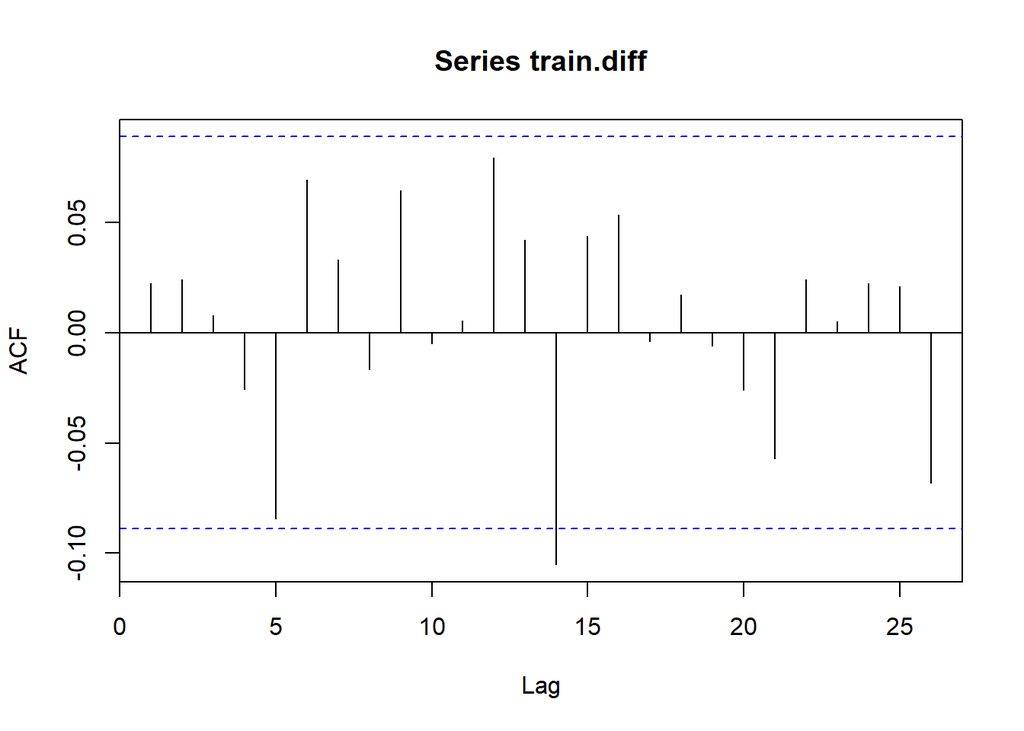

```r
acf(train.diff)
```

Berdasarkan plot tersebut, terlihat bahwa plot ACF tails off dan membentuk pola naik turun.

#### Uji ADF

```r
tseries::adf.test(train.diff)
```

```
##
##  Augmented Dickey-Fuller Test
##
## data:  train.diff
## Dickey-Fuller = -7.9149, Lag order = 7, p-value = 0.01
## alternative hypothesis: stationary
```

Berdasarkan uji ADF tersebut, didapat *p-value* sebesar 0.01 yang lebih kecil dari taraf nyata 5% sehingga menandakan bahwa data sudah stasioner dalam rataan.

## Identifikasi Model

### Plot ACF

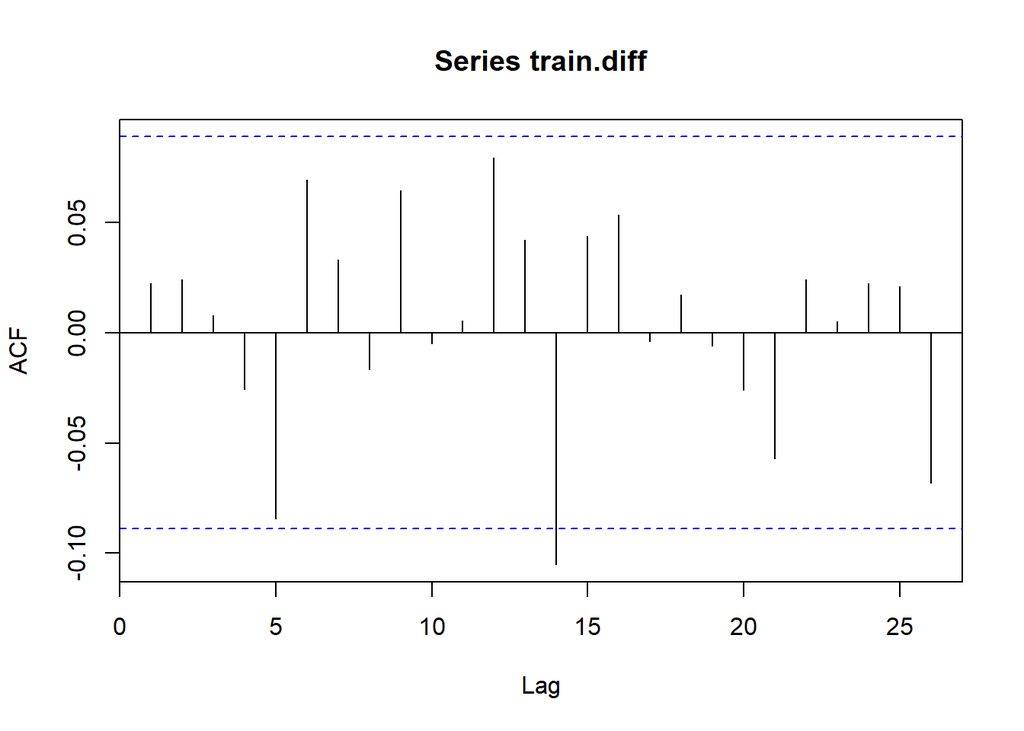

```r
acf(train.diff)
```

Berdasarkan plot tersebut, terlihat bahwa plot ACF cenderung *tails of*.

### Plot PACF

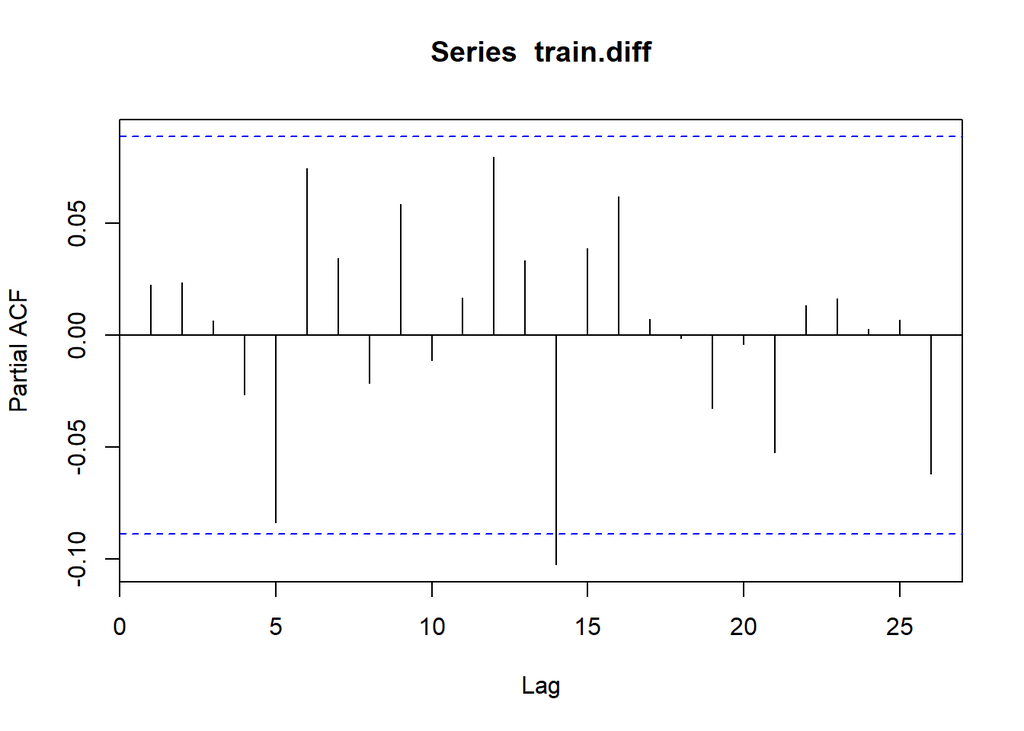

```r
pacf(train.diff)
```

Berdasarkan plot tersebut, terlihat bahwa plot PACF cenderung *tails off*.

### Plot EACF

```r
eacf(train.diff)
```

```
## AR/MA
##   0 1 2 3 4 5 6 7 8 9 10 11 12 13
## 0 o o o o o o o o o o o  o  o  x
## 1 x o o o o o o o o o o  o  o  o
## 2 x x o o o o o o o o o  o  o  o
## 3 x x o o o o o o o o o  o  o  o
## 4 x x x x o o o o o o o  o  o  o
## 5 x x x x x o o o o o o  o  o  o
## 6 x x x x x o o o o o o  o  o  o
## 7 x x x o x x o o o o o  o  o  o
```

Identifikasi model menggunakan plot EACF dilakukan dengan melihat ujung segitiga pada pola segitiga nol. Dalam hal ini model tentatif yang terbentuk adalah ARIMA(1,1,2), ARIMA(1,1,1), ARIMA(0,1,1), ARIMA(0,1,2), ARIMA(0,1,3), ARIMA(1,1,3), ARIMA(2,1,3),ARIMA(3,1,3).

## Pendugaan Parameter Model Tentatif

### ARIMA(0,1,1)

```r
model1=Arima(train.diff, order=c(0,1,1),method="ML")
summary(model1)
```

```
## Series: train.diff
## ARIMA(0,1,1)
##
## Coefficients:
##           ma1
##       -0.9908
## s.e.   0.0064
##
## sigma^2 = 0.002243:  log likelihood = 791.2
## AIC=-1578.41   AICc=-1578.38   BIC=-1570.03
##
## Training set error measures:
##                       ME       RMSE        MAE       MPE     MAPE      MASE
## Training set 0.002897575 0.04726065 0.03340313 -242.7543 473.4942 0.7877285
##                    ACF1
## Training set 0.01060629
```

```r
lmtest::coeftest(model1)
```

```
##
## z test of coefficients:
##
##       Estimate Std. Error z value  Pr(>|z|)
## ma1 -0.9908435  0.0063952 -154.94 < 2.2e-16 ***
## ---
## Signif. codes:  0 '***' 0.001 '**' 0.01 '*' 0.05 '.' 0.1 ' ' 1
```

### ARIMA(1,1,1)

```r
model2=Arima(train.diff, order=c(1,1,1),method="ML")
summary(model2)
```

```
## Series: train.diff
## ARIMA(1,1,1)
##
## Coefficients:
##          ar1      ma1
##       0.0161  -0.9910
## s.e.  0.0457   0.0064
##
## sigma^2 = 0.002247:  log likelihood = 791.27
## AIC=-1576.53   AICc=-1576.48   BIC=-1563.97
##
## Training set error measures:
##                       ME       RMSE        MAE       MPE     MAPE      MASE
## Training set 0.002880472 0.04725511 0.03328921 -237.3781 463.2227 0.7850418
##                      ACF1
## Training set -0.005614265
```

```r
lmtest::coeftest(model2)
```

```
##
## z test of coefficients:
##
##      Estimate Std. Error   z value Pr(>|z|)
## ar1  0.016109   0.045660    0.3528   0.7242
## ma1 -0.991036   0.006391 -155.0672   <2e-16 ***
## ---
## Signif. codes:  0 '***' 0.001 '**' 0.01 '*' 0.05 '.' 0.1 ' ' 1
```

### ARIMA(1,1,2)

```r
model3=Arima(train.diff, order=c(1,1,2),method="ML")
summary(model3)
```

```
## Series: train.diff
## ARIMA(1,1,2)
##
## Coefficients:
##           ar1      ma1      ma2
##       -0.3635  -0.6194  -0.3680
## s.e.   6.6312   6.4394   6.3787
##
## sigma^2 = 0.002252:  log likelihood = 791.22
## AIC=-1574.44   AICc=-1574.36   BIC=-1557.7
##
## Training set error measures:
##                       ME       RMSE        MAE       MPE     MAPE      MASE
## Training set 0.002885866 0.04725929 0.03336188 -242.6058 471.3319 0.7867557
##                     ACF1
## Training set 0.002580642
```

```r
lmtest::coeftest(model3)
```

```
##
## z test of coefficients:
##
##     Estimate Std. Error z value Pr(>|z|)
## ar1 -0.36352    6.63116 -0.0548   0.9563
## ma1 -0.61944    6.43937 -0.0962   0.9234
## ma2 -0.36804    6.37870 -0.0577   0.9540
```

### ARIMA(0,1,2)

```r
model4=Arima(train.diff, order=c(0,1,2),method="ML")
summary(model4)
```

```
## Series: train.diff
## ARIMA(0,1,2)
##
## Coefficients:
##           ma1      ma2
##       -0.9755  -0.0154
## s.e.   0.0446   0.0445
##
## sigma^2 = 0.002247:  log likelihood = 791.26
## AIC=-1576.53   AICc=-1576.48   BIC=-1563.97
##
## Training set error measures:
##                       ME       RMSE        MAE       MPE     MAPE     MASE
## Training set 0.002886825 0.04725512 0.03329358 -237.4114 463.3366 0.785145
##                      ACF1
## Training set -0.005077359
```

```r
lmtest::coeftest(model4)
```

```
##
## z test of coefficients:
##
##      Estimate Std. Error  z value Pr(>|z|)
## ma1 -0.975476   0.044605 -21.8694   <2e-16 ***
## ma2 -0.015443   0.044463  -0.3473   0.7283
## ---
## Signif. codes:  0 '***' 0.001 '**' 0.01 '*' 0.05 '.' 0.1 ' ' 1
```

### ARIMA(0,1,3)

```r
model5=Arima(train.diff, order=c(0,1,3),method="ML")
summary(model5)
```

```
## Series: train.diff
## ARIMA(0,1,3)
##
## Coefficients:
##           ma1     ma2      ma3
##       -0.9753  0.0031  -0.0188
## s.e.   0.0453  0.0648   0.0467
##
## sigma^2 = 0.002251:  log likelihood = 791.34
## AIC=-1574.69   AICc=-1574.61   BIC=-1557.94
##
## Training set error measures:
##                      ME       RMSE        MAE       MPE     MAPE      MASE
## Training set 0.00286528 0.04724773 0.03320703 -223.7425 448.1356 0.7831038
##                      ACF1
## Training set -0.005236042
```

```r
lmtest::coeftest(model5)
```

```
##
## z test of coefficients:
##
##       Estimate Std. Error  z value Pr(>|z|)
## ma1 -0.9753165  0.0453500 -21.5064   <2e-16 ***
## ma2  0.0030928  0.0647793   0.0477   0.9619
## ma3 -0.0187736  0.0467076  -0.4019   0.6877
## ---
## Signif. codes:  0 '***' 0.001 '**' 0.01 '*' 0.05 '.' 0.1 ' ' 1
```

### ARIMA(1,1,3)

```r
model6=Arima(train.diff, order=c(1,1,3),method="ML")
summary(model6)
```

```
## Series: train.diff
## ARIMA(1,1,3)
##
## Coefficients:
```

```
##         ar1      ma1      ma2      ma3
##       -0.37  -0.6054  -0.3621  -0.0201
## s.e.    NaN      NaN      NaN   0.0400
##
## sigma^2 = 0.002256:  log likelihood = 791.33
## AIC=-1572.66   AICc=-1572.53   BIC=-1551.73
##
## Training set error measures:
##                       ME       RMSE        MAE       MPE     MAPE      MASE
## Training set 0.002877118 0.04724905 0.03323011 -226.6569 451.1601 0.7836481
##                     ACF1
## Training set -0.00508123
```

```r
lmtest::coeftest(model6)
```

```
##
## z test of coefficients:
##
##      Estimate Std. Error z value Pr(>|z|)
## ar1 -0.369970        NaN     NaN      NaN
## ma1 -0.605444        NaN     NaN      NaN
## ma2 -0.362126        NaN     NaN      NaN
## ma3 -0.020065   0.040018 -0.5014   0.6161
```

### ARIMA(2,1,3)

```r
model7=Arima(train.diff, order=c(2,1,3),method="ML")
summary(model7)
```

```
## Series: train.diff
## ARIMA(2,1,3)
##
## Coefficients:
```

```
##           ar1     ar2      ma1      ma2     ma3
##       -0.3041  0.1687  -0.6719  -0.4603  0.1424
## s.e.      NaN  0.2787      NaN      NaN  0.3493
##
## sigma^2 = 0.00226:  log likelihood = 791.37
## AIC=-1570.73   AICc=-1570.56   BIC=-1545.61
##
## Training set error measures:
##                       ME       RMSE        MAE       MPE     MAPE      MASE
## Training set 0.002880292 0.04724522 0.03320421 -221.1289 445.8733 0.7830373
##                      ACF1
## Training set -0.004169213
```

```r
lmtest::coeftest(model7)
```

```
##
## z test of coefficients:
##
##     Estimate Std. Error z value Pr(>|z|)
## ar1 -0.30410        NaN     NaN      NaN
## ar2  0.16870    0.27875  0.6052   0.5450
## ma1 -0.67194        NaN     NaN      NaN
## ma2 -0.46035        NaN     NaN      NaN
## ma3  0.14242    0.34934  0.4077   0.6835
```

### ARIMA(2,1,2)

```r
model8=Arima(train.diff, order=c(2,1,2),method="ML")
summary(model8)
```

```
## Series: train.diff
## ARIMA(2,1,2)
##
## Coefficients:
```

```
##           ar1     ar2      ma1      ma2
##       -0.3592  0.0219  -0.6158  -0.3722
## s.e.      NaN  0.0407      NaN      NaN
##
## sigma^2 = 0.002256:  log likelihood = 791.34
## AIC=-1572.67   AICc=-1572.55   BIC=-1551.74
##
## Training set error measures:
##                       ME       RMSE        MAE      MPE     MAPE      MASE
## Training set 0.002876761 0.04724826 0.03321974 -225.139 449.4032 0.7834037
##                      ACF1
## Training set -0.005498193
```

```r
lmtest::coeftest(model8)
```

```
##
## z test of coefficients:
##
##      Estimate Std. Error z value Pr(>|z|)
## ar1 -0.359185        NaN     NaN      NaN
## ar2  0.021886   0.040745  0.5371   0.5912
## ma1 -0.615794        NaN     NaN      NaN
## ma2 -0.372162        NaN     NaN      NaN
```

### ARIMA(3,1,3)

```r
model9=Arima(train.diff, order=c(3,1,3),method="ML")
summary(model9)
```

```
## Series: train.diff
## ARIMA(3,1,3)
##
## Coefficients:
```

```
##           ar1      ar2     ar3      ma1     ma2      ma3
##       -0.8437  -0.9765  0.0255  -0.1194  0.1295  -0.9842
## s.e.   0.0338   0.0313  0.0406      NaN  0.0098      NaN
##
## sigma^2 = 0.002205:  log likelihood = 796.94
## AIC=-1579.87   AICc=-1579.64   BIC=-1550.57
##
## Training set error measures:
##                       ME       RMSE        MAE       MPE     MAPE     MASE
## Training set 0.002855091 0.04661773 0.03338102 -237.6248 575.9332 0.787207
##                      ACF1
## Training set -0.005643339
```

```r
lmtest::coeftest(model9)
```

```
##
## z test of coefficients:
##
##       Estimate Std. Error  z value Pr(>|z|)
## ar1 -0.8437091  0.0338499 -24.9250   <2e-16 ***
## ar2 -0.9764616  0.0312902 -31.2066   <2e-16 ***
## ar3  0.0255346  0.0405771   0.6293   0.5292
## ma1 -0.1193715        NaN      NaN      NaN
## ma2  0.1294607  0.0097523  13.2749   <2e-16 ***
## ma3 -0.9841932        NaN      NaN      NaN
## ---
## Signif. codes:  0 '***' 0.001 '**' 0.01 '*' 0.05 '.' 0.1 ' ' 1
```

Model yang dipilih yaitu model pertama ARIMA(0,1,1) karena semua parameter signifikan dan nilai AIC yang kecil.

## Eksplorasi Sisaan

### Eksplorasi Sisaan

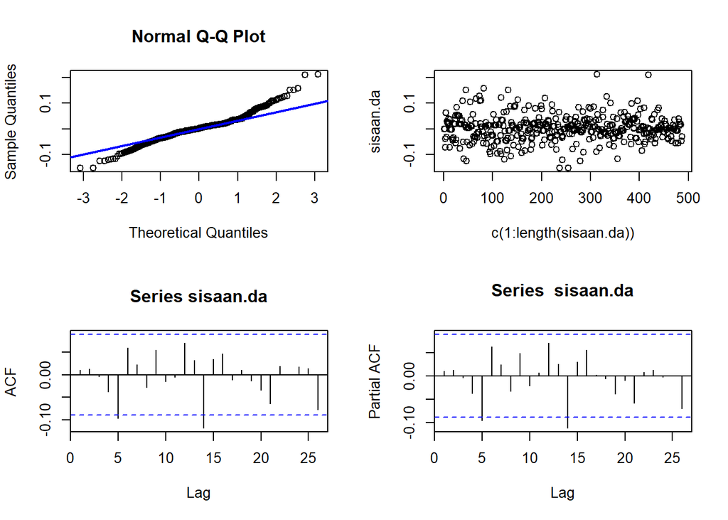

```r
#Eksplorasi
sisaan.da <- model1$residuals
par(mfrow=c(2,2))
qqnorm(sisaan.da)
qqline(sisaan.da, col = "blue", lwd = 2)
plot(c(1:length(sisaan.da)),sisaan.da)
acf(sisaan.da)
pacf(sisaan.da)
```

```r
par(mfrow = c(1,1))
```

Berdasarkan plot kuantil-kuantil normal, secara eksplorasi ditunjukkan sisaan tidak menyebar normal ditandai dengan titik titik yang cenderung tidak mengikuti garis. Kemudian dapat dilihat juga lebar pita sisaan yang cenderung sama menandakan bahwa sisaan memiliki ragam yang homogen. Selain itu dapat dilihat juga bahwa sisaan saling bebas.

### Uji Formal

```r
# Sisaan Menyebar Normal
shapiro.test(sisaan.da)
```

```
##
##  Shapiro-Wilk normality test
##
## data:  sisaan.da
## W = 0.96016, p-value = 3.321e-10
```

Berdasarkan uji Shapiro-Wilk tersebut, didapat *p-value* sebesar 3.321e-10 yang kurang dari taraf nyata 5% sehingga tolak $H_0$ dan menandakan bahwa sisaan tidak menyebar normal. Hal ini sesuai dengan hasil eksplorasi menggunakan plot kuantil-kuantil normal.

```r
# Sisaan Saling Bebas
Box.test(sisaan.da, type = "Ljung")
```

```
##
##  Box-Ljung test
##
## data:  sisaan.da
## X-squared = 0.055122, df = 1, p-value = 0.8144
```

Berdasarkan uji Ljung-Box tersebut, didapat *p-value* sebesar 0.8144 yang lebih besar dari taraf nyata 5% sehingga tak tolak $H_0$ dan menandakan bahwa sisaan saling bebas.

```r
# Sisaan Homogen
Box.test((sisaan.da)^2, type = "Ljung")
```

```
##
##  Box-Ljung test
##
## data:  (sisaan.da)^2
## X-squared = 0.54991, df = 1, p-value = 0.4584
```

Berdasarkan uji Ljung-Box terhadap sisaan kuadrat tersebut, didapat *p-value* sebesar 0.4584 yang lebih dari taraf nyata 5% sehingga terima $H_0$ dan menandakan bahwa ragam sisaan homogen.

```r
# Nilai tengah sisaan sama dengan nol
t.test(sisaan.da, mu = 0, conf.level = 0.95)
```

```
##
##  One Sample t-test
##
## data:  sisaan.da
## t = 1.3542, df = 486, p-value = 0.1763
## alternative hypothesis: true mean is not equal to 0
## 95 percent confidence interval:
##  -0.001306735  0.007101885
## sample estimates:
##   mean of x
## 0.002897575
```

Berdasarkan uji-ttersebut, didapat *p-value* sebesar 0.1763 yang lebih besar dari taraf nyata 5% sehingga tak tolak $H_0$ dan menandakan bahwa nilai tengah sisaan sama dengan nol.

## Overfitting

### ARIMA(1,1,1)

```r
model10=Arima(train.diff, order=c(1,1,1),method="ML")
summary(model10)
```

```
## Series: train.diff
## ARIMA(1,1,1)
##
## Coefficients:
##          ar1      ma1
##       0.0161  -0.9910
## s.e.  0.0457   0.0064
##
## sigma^2 = 0.002247:  log likelihood = 791.27
## AIC=-1576.53   AICc=-1576.48   BIC=-1563.97
##
## Training set error measures:
##                       ME       RMSE        MAE       MPE     MAPE      MASE
## Training set 0.002880472 0.04725511 0.03328921 -237.3781 463.2227 0.7850418
##                      ACF1
## Training set -0.005614265
```

```r
lmtest::coeftest(model10)
```

```
##
## z test of coefficients:
##
##      Estimate Std. Error   z value Pr(>|z|)
## ar1  0.016109   0.045660    0.3528   0.7242
## ma1 -0.991036   0.006391 -155.0672   <2e-16 ***
## ---
## Signif. codes:  0 '***' 0.001 '**' 0.01 '*' 0.05 '.' 0.1 ' ' 1
```

Berdasarkan model overfitting pertama, didapatkan nilai *AIC* sebesar **-1576.53** dan satu parameter signifikan.

### ARIMA(0,1,2)

```r
model11=Arima(train.diff, order=c(0,1,2),method="ML")
summary(model11)
```

```
## Series: train.diff
## ARIMA(0,1,2)
##
## Coefficients:
##           ma1      ma2
##       -0.9755  -0.0154
## s.e.   0.0446   0.0445
##
## sigma^2 = 0.002247:  log likelihood = 791.26
## AIC=-1576.53   AICc=-1576.48   BIC=-1563.97
##
## Training set error measures:
##                       ME       RMSE        MAE       MPE     MAPE     MASE
## Training set 0.002886825 0.04725512 0.03329358 -237.4114 463.3366 0.785145
##                      ACF1
## Training set -0.005077359
```

```r
lmtest::coeftest(model11)
```

```
##
## z test of coefficients:
##
##      Estimate Std. Error  z value Pr(>|z|)
## ma1 -0.975476   0.044605 -21.8694   <2e-16 ***
## ma2 -0.015443   0.044463  -0.3473   0.7283
## ---
## Signif. codes:  0 '***' 0.001 '**' 0.01 '*' 0.05 '.' 0.1 ' ' 1
```

Berdasarkan model overfitting kedua, didapatkan nilai *AIC* sebesar **-1576.53** dan satu parameter signifikan.

Karena pada model ARIMA(0,1,1) memiliki *AIC* yang lebih kecil dari kedua model overfitting dan semua parameter signifikan, maka dipilih model ARIMA(0,1,1).

## Peramalan

```r
ramalan.da <- forecast::forecast(model1, h = length(test.ts))
ramalan.da
```

```
##     Point Forecast       Lo 80      Hi 80       Lo 95      Hi 95
## 489    0.004154991 -0.05653679 0.06484677 -0.08866507 0.09697506
## 490    0.004154991 -0.05653933 0.06484931 -0.08866897 0.09697895
## 491    0.004154991 -0.05654188 0.06485186 -0.08867286 0.09698284
## 492    0.004154991 -0.05654442 0.06485440 -0.08867675 0.09698673
## 493    0.004154991 -0.05654696 0.06485695 -0.08868064 0.09699062
## 494    0.004154991 -0.05654951 0.06485949 -0.08868453 0.09699451
## 495    0.004154991 -0.05655205 0.06486203 -0.08868842 0.09699840
## 496    0.004154991 -0.05655459 0.06486458 -0.08869231 0.09700229
## 497    0.004154991 -0.05655714 0.06486712 -0.08869620 0.09700618
## 498    0.004154991 -0.05655968 0.06486966 -0.08870009 0.09701007
## 499    0.004154991 -0.05656222 0.06487221 -0.08870398 0.09701396
## 500    0.004154991 -0.05656477 0.06487475 -0.08870787 0.09701785
## 501    0.004154991 -0.05656731 0.06487729 -0.08871176 0.09702174
## 502    0.004154991 -0.05656985 0.06487984 -0.08871564 0.09702563
```

[output cut: 72 more lines]

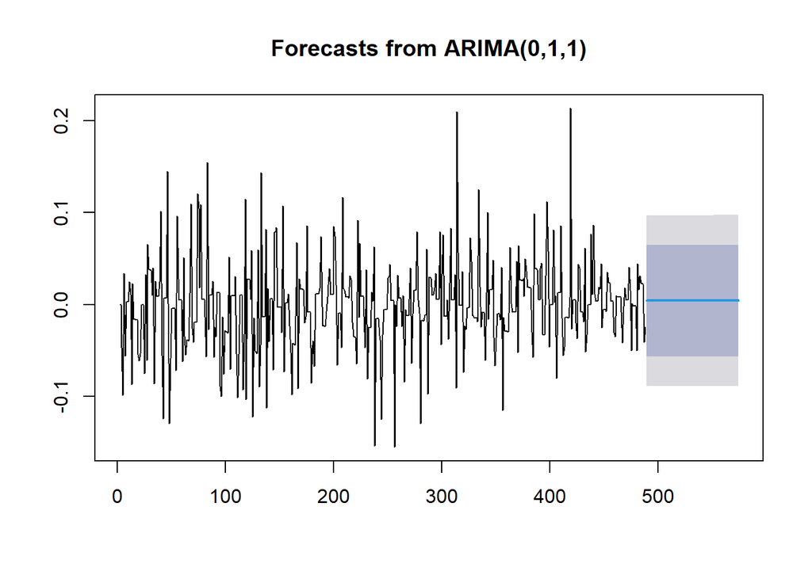

```r
data.ramalan.da <- ramalan.da$mean
plot(ramalan.da)
```

Berdasarkan hasil plot ramalan di atas, dapat dilihat bahwa ramalan ARIMA(0,1,1) cenderung stabil hingga akhir periode. Selanjutnya, dapat dicari nilai akurasi antara hasil ramalan dengan data uji.

## Akurasi

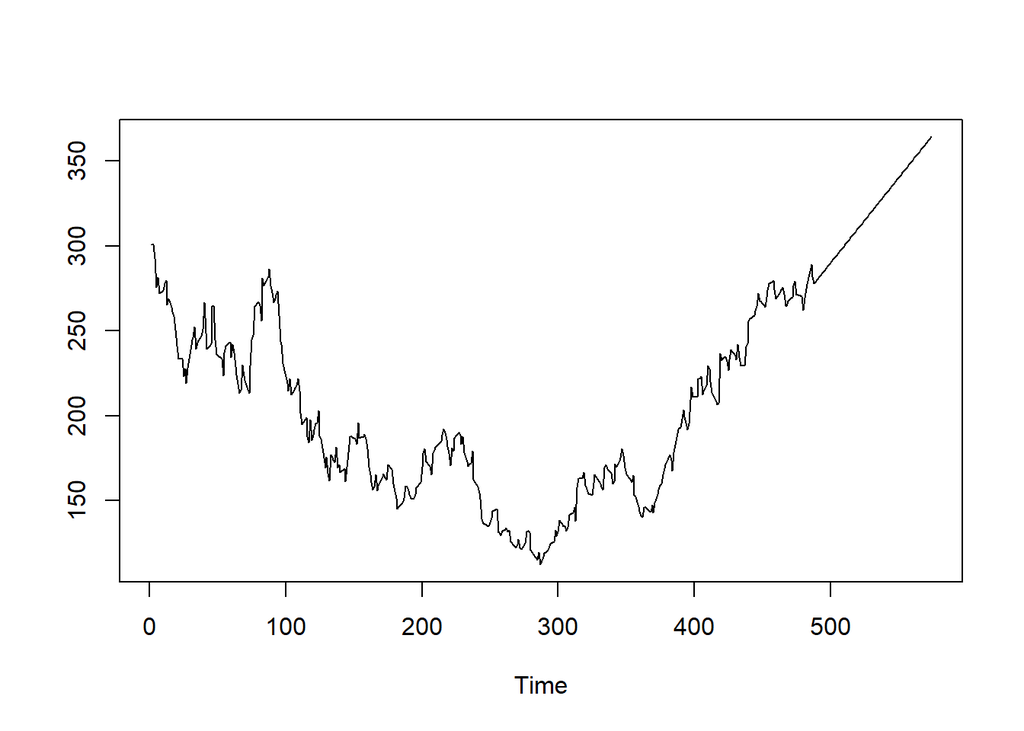

```r
pt_1 <- train.ts[488]
hasil.forc.Diff <- data.ramalan.da
hasil<-((hasil.forc.Diff*lambda)+1)^(1/lambda)
hasil <- diffinv(hasil, differences = 1) + pt_1
ts.plot(train.ts,hasil)
```

```r
perbandingan.da<-matrix(data=c(head(test.ts, n=length(test.ts)), hasil[-1]),
                     nrow = length(test.ts), ncol = 2)
colnames(perbandingan.da)<-c("Aktual","Hasil Forecast")
perbandingan.da
```

```
##         Aktual Hasil Forecast
##  [1,] 275.5915       278.9954
##  [2,] 286.7703       279.9995
##  [3,] 288.3402       281.0037
##  [4,] 289.9100       282.0079
##  [5,] 291.4799       283.0120
##  [6,] 285.6804       284.0162
##  [7,] 288.8201       285.0204
##  [8,] 285.7504       286.0245
##  [9,] 283.3707       287.0287
## [10,] 285.4138       288.0328
## [11,] 287.4569       289.0370
## [12,] 289.5000       290.0412
## [13,] 292.0998       291.0453
## [14,] 301.7488       292.0495
```

[output cut: 72 more lines]

```r
accuracy(ts(hasil[-1]), head(test.ts, n=length(test.ts)))
```

```
##                ME     RMSE      MAE      MPE     MAPE      ACF1 Theil's U
## Test set 69.51324 79.08394 69.79408 16.57158 16.67103 0.9330256   5.80953
```

Peramalan memberikan nilai *MAPE* sebesar **16.67103** yang lebih besar dari 10. Maka dapat disimpulkan bahwa peramalan cukup baik.